# Machine Learning: Clustering de document

Hurgland-Nick KELIET

Le Clustering est une technique de Machine Learning très populaire et dite non supervisé. Grâce au Clustering, nous pouvons faire de l’analyse de haut niveau, comme analyser des données de réseaux sociaux, moteurs de recherches, performance académique ou encore faire de la segmentation de marché.

Dans cet article, je parlerais du **CLUSTERING DE TEXTE**, mais surtout, d’un algo de Clustering très important et très populaire pour performer ce type d’analyse, le **K-Means**(*Clustering partitionnel*) et le Clustering Hiérarchique.

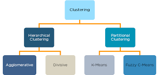

Les données de ce tutoriel ce trouve sur ce lien: dailykos.csv Ces données ont été générées en un seul dataset grâce à l’assemblage d’une multitude d’articles environ 3000 et a été publié sur le journal Daily Kos, un blog politique Americain qui publie des articles d’actualité et d’opinion écrits d’un point de vue progressiste.

Ces articles ici présents traitent de l’élection présidentielle des Etats-unis en 2004, dont les principaux candidats fût le président sortant Georges Bush (Républicain) et John Kerry (Démocrate).

Grâce au K-Means on va performer des divisions d’objets en Clusters qui sont “similaire”, sans oublier de passer par des techniques d’analyse de texte.

### Chargement des librairies

```r
# Tidyverse
suppressWarnings(library(tidyverse))
```

### Chargement des données

```r
dailykos <- read.csv("https://raw.githubusercontent.com/eugenedobro/The-Analytic-Edge/master/Unit%206%20Cluster/dailykos.csv")
#head(dailykos)
```

### Dimension du dataframe

```r
message(paste0("Le dataset dailykos a "),nrow(dailykos)," lignes et ", ncol(dailykos), " colonnes")
```

```
## Le dataset dailykos a 3430 lignes et 1545 colonnes
```

# HIERARCHICAL CLUSTERING (hclust 😉)

- 1. Calcul de la distance : Distance <- dist(data, method = “euclidean/canberra/minkowski/maximum”)
- 2. cluster = hclust(Distance, method = "")

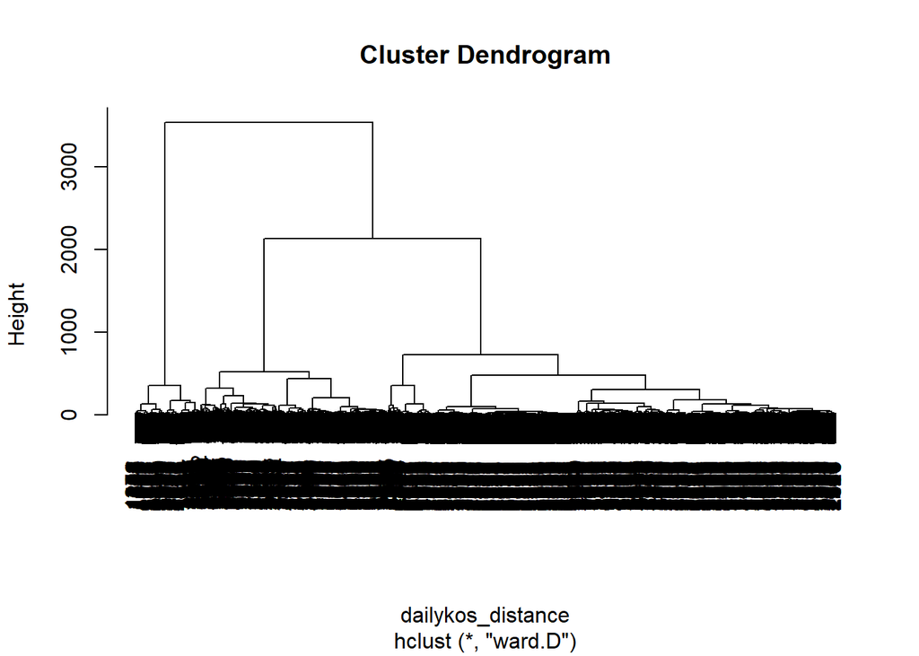

```r
# 1) Calcul de la distance entre les documents en utilisant la fonction "dist"
# @ Ici nous choisissons la distance Euclidienne, il y'en a bien d'autres comme Manhattan, cosine etc...
dailykos_distance <- dist(dailykos, method = "euclidean")

# 2) Le Clustering Hiérarchique
# @ Ici Ward.D = Prend en compte la distance entre les variances et les centroïdes.
dailykos_cluster = hclust(dailykos_distance, method = "ward.D")

# Affichons notre dendrogramme du modèle de clustering hiérarchique
plot(dailykos_cluster)
```

Nous observons une multitude d’observations (champs noirs) qui nous empêche d’appliquer des fonctions comme tapply, puisque nous avons plus de 1000 variables différentes.

Assignons des points à nos clusters , et traçons 7 clusters en rouge: rect.hclust <- (data_hclust, k = n_clusters, border = “color”)

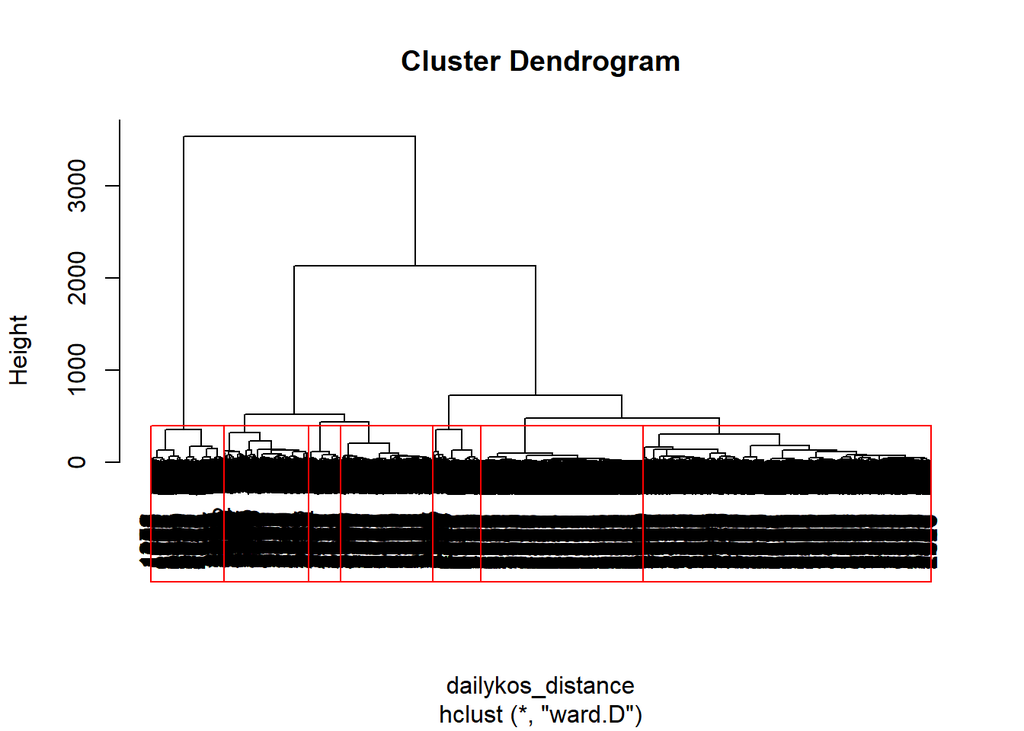

```r
# Graphe principal
plot(dailykos_cluster)

# Zone des 7 clusters
rect.hclust(dailykos_cluster, k = 7)
```

### Groupe de Cluster

**Créons 7 groupes de clusters données.**

```r
Cluster_Hierarchique_dailykos <- cutree(dailykos_cluster, k = 7)
```

**Nombre d’observations par Cluster.**

```r
# Méthode 1
table(Cluster_Hierarchique_dailykos)
```

```
## Cluster_Hierarchique_dailykos
##    1    2    3    4    5    6    7
## 1266  321  374  139  407  714  209
```

```r
# Méthode 2 : Naïve
HCluster_1 = subset(dailykos, Cluster_Hierarchique_dailykos == 1)
HCluster_2 = subset(dailykos, Cluster_Hierarchique_dailykos == 2)
HCluster_3 = subset(dailykos, Cluster_Hierarchique_dailykos == 3)
HCluster_4 = subset(dailykos, Cluster_Hierarchique_dailykos == 4)
HCluster_5 = subset(dailykos, Cluster_Hierarchique_dailykos == 5)
HCluster_6 = subset(dailykos, Cluster_Hierarchique_dailykos == 6)
HCluster_7 = subset(dailykos, Cluster_Hierarchique_dailykos == 7)


# Méthode 3 : Création d'un dataframe
nombre_observations <- c()
for (i in table(Cluster_Hierarchique_dailykos)){
  nombre_observations <- c(nombre_observations, i)
}
nombre_observations <- data.frame(Cluster = seq(1:7), nombre_observations)
nombre_observations
```

```
##   Cluster nombre_observations
## 1       1                1266
## 2       2                 321
## 3       3                 374
## 4       4                 139
## 5       5                 407
## 6       6                 714
## 7       7                 209
```

On peut voir que les Clusters 1 et 6 sont les plus gros

### Les mots les plus fréquents dans le premier cluster

```r
Les_mots_les_plus_frequent <- tail(sort(colMeans(HCluster_1)))
Les_mots_les_plus_frequent
```

```
##      state republican       poll   democrat      kerry       bush
##  0.7575039  0.7590837  0.9036335  0.9194313  1.0624013  1.7053712
```

### Les mots les plus fréquents dans chaque Cluster (Top 7)

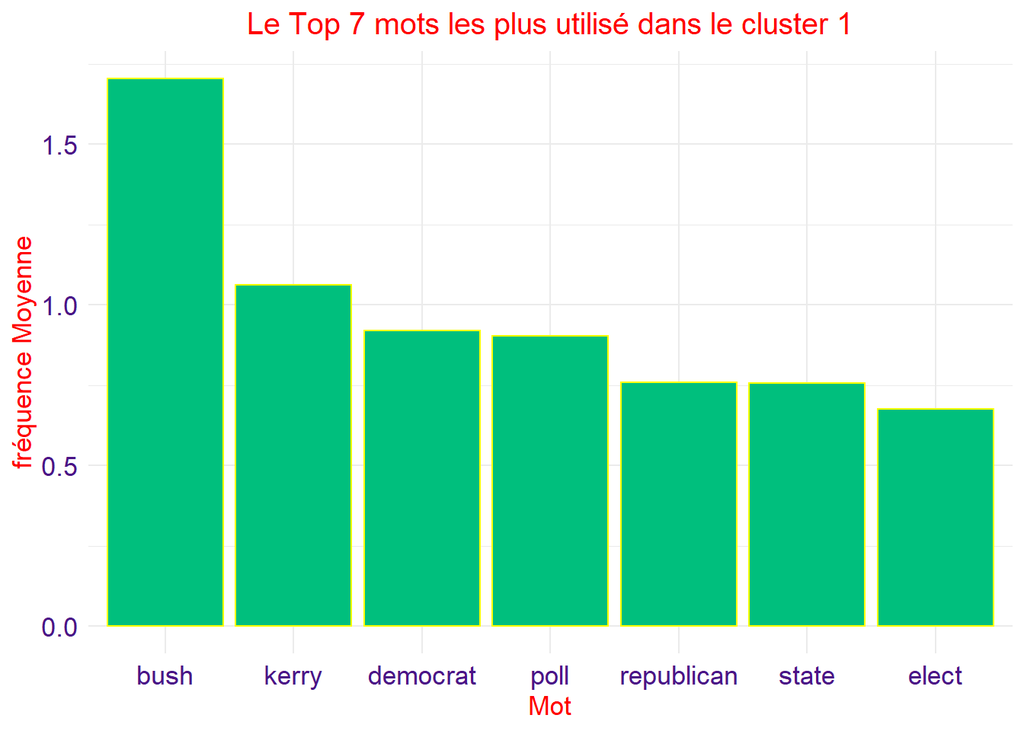

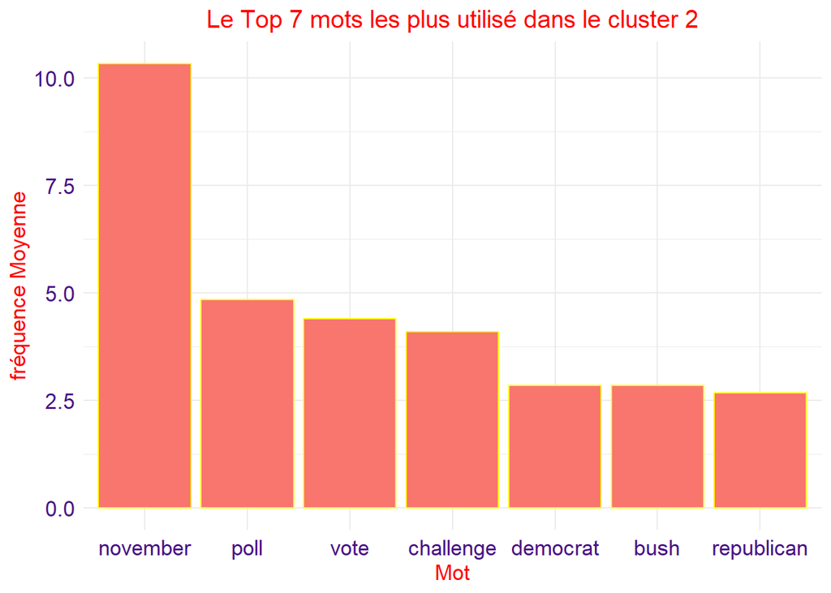

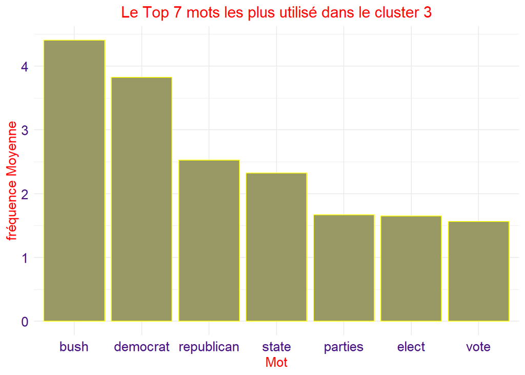

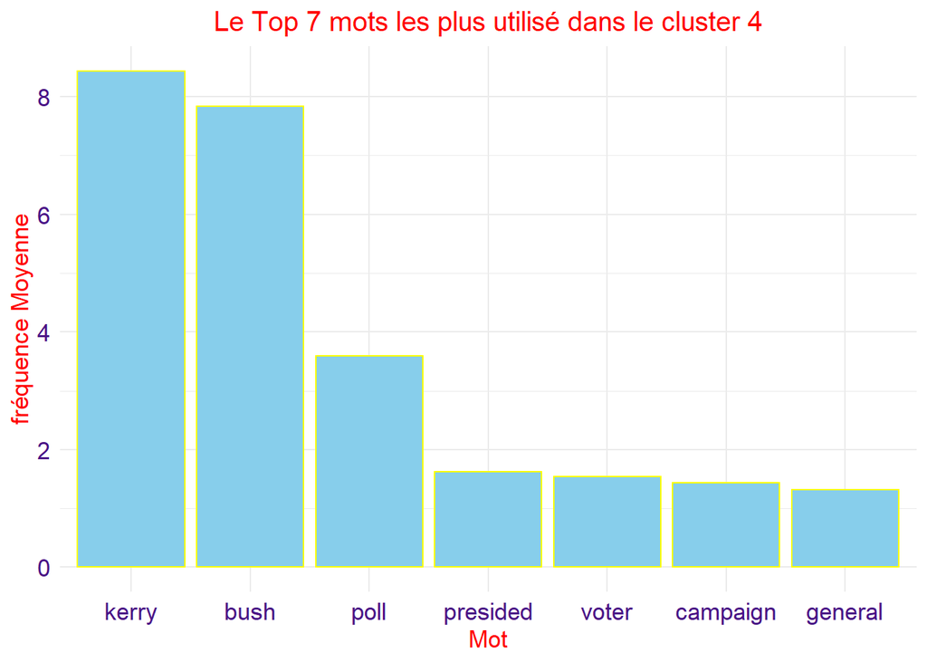

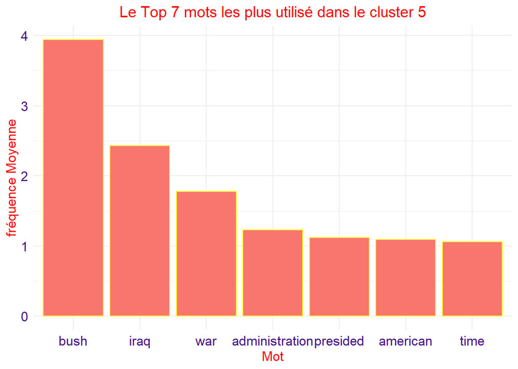

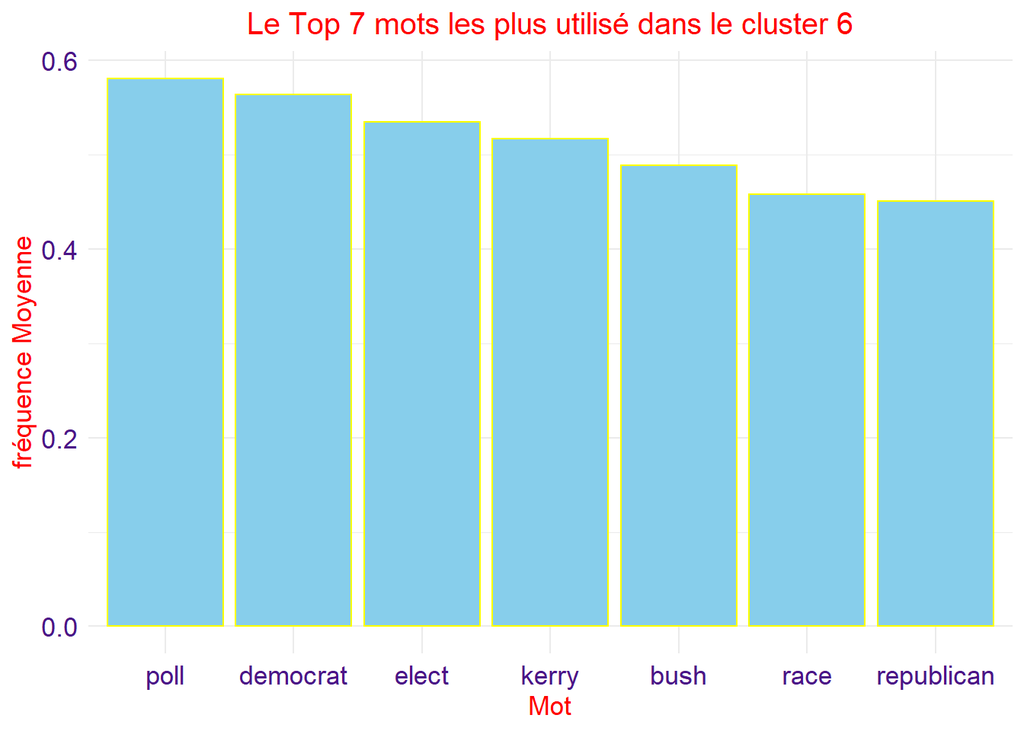

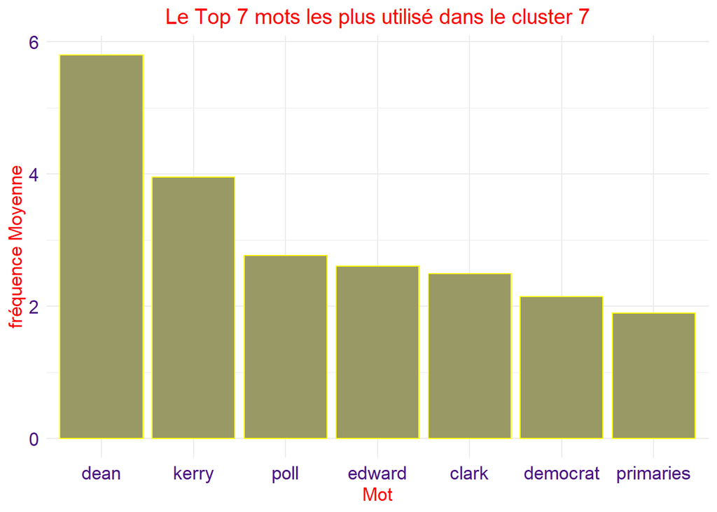

```r
for(i in seq(1,7)){
  top_7_mots <- tail(sort(colMeans(subset(dailykos, Cluster_Hierarchique_dailykos == i))),7)

  # Récupération de la liste des noms des colonnes
  liste_des_mots <- names(top_7_mots)

  # Récupération des valeurs de la fréquence de chaque mots
  moyenne_mots <- as.vector(top_7_mots)

  # Créons un dataframe avec le nom et la valeur de chaque mot
  df_top_7_mots <- data.frame(Mot = liste_des_mots,Moyenne_mots = moyenne_mots)

  # Organisons cela par ordre décroissant
  df_top_7_mots$Mot <- factor(df_top_7_mots$Mot, levels = df_top_7_mots$Mot[order(df_top_7_mots$Moyenne_mots,decreasing = TRUE)])

  # Palette de couleur
  palette_de_couleur <- c('#F8766D','#999966','#79a6d2','#00BF7D','orange','skyblue','#F8766D')

  # Création des graphes
  graphe_top_7_mots <- ggplot(df_top_7_mots, aes(x = Mot, y = Moyenne_mots)) +
                       geom_bar(stat = "identity", color = "yellow", fill = sample(palette_de_couleur,1,replace = TRUE)) +
                       theme_minimal() +
                       ggtitle(paste("Le Top 7 mots les plus utilisé dans le cluster",i)) +
                       xlab("Mot") +
                       ylab("fréquence Moyenne") +
                       theme(plot.title = element_text(size = 15,colour="red", hjust = 0.5))+
                       theme(axis.text.x = element_text(size = 13, color = "#4A1486", ),
                             axis.text.y = element_text(size = 13, color = "#4A1486"),
                             axis.title.x = element_text(size = 13, color = "red"),
                             axis.title.y = element_text(size = 13, color = "red"))


  # Afficher les graphes
  plot(graphe_top_7_mots)
}
```

# K-Means Clustering (😎😉😜)

**Créons 7 groupes de clusters données.**

```r
# 1) Paramétrer le seed à 1000 pour le rendre stable et avoir une bonne précision
set.seed(1000)

# 2) Instanciation du K-Means en créant 7 Clusters
KMeans_cluster = kmeans(dailykos, centers = 7)
```

**Variable de nos Clusters**

```r
names(KMeans_cluster)
```

```
## [1] "cluster"      "centers"      "totss"        "withinss"     "tot.withinss"
## [6] "betweenss"    "size"         "iter"         "ifault"
```

**Nombre d’observations dans chaque cluster.**

```r
table(KMeans_cluster[1])
```

```
##
##    1    2    3    4    5    6    7
##  150  329  300 2027  144  275  205
```

```r
# Méthode 2 :
Kmeans_Cluster_1 = subset(dailykos, KMeans_cluster$cluster == 1)
Kmeans_Cluster_2 = subset(dailykos, KMeans_cluster$cluster == 2)
Kmeans_Cluster_3 = subset(dailykos, KMeans_cluster$cluster == 3)
Kmeans_Cluster_4 = subset(dailykos, KMeans_cluster$cluster == 4)
Kmeans_Cluster_5 = subset(dailykos, KMeans_cluster$cluster == 5)
Kmeans_Cluster_6 = subset(dailykos, KMeans_cluster$cluster == 6)
Kmeans_Cluster_7 = subset(dailykos, KMeans_cluster$cluster == 7)

# Méthode 3 : Création d'un dataframe
nombre_observations_Kmeans <- c()
for (i in seq(1,7)){
  nombre_observations_Kmeans <- c(nombre_observations_Kmeans,dim(dailykos[KMeans_cluster$cluster == i,])[1])
}
nombre_observations_Kmeans <- data.frame(list(cluster=c(1:7), Nombre_observation = nombre_observations_Kmeans))
nombre_observations_Kmeans
```

```
##   cluster Nombre_observation
## 1       1                150
## 2       2                329
## 3       3                300
## 4       4               2027
## 5       5                144
## 6       6                275
## 7       7                205
```

**Visualisation des centres**

```r
# KMeans_cluster$centers
```

### Les mots les plus fréquents dans chaque Cluster (Top 7 KMeans Clustering)

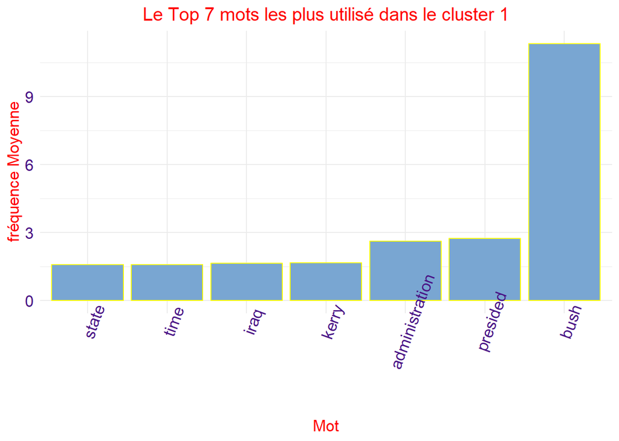

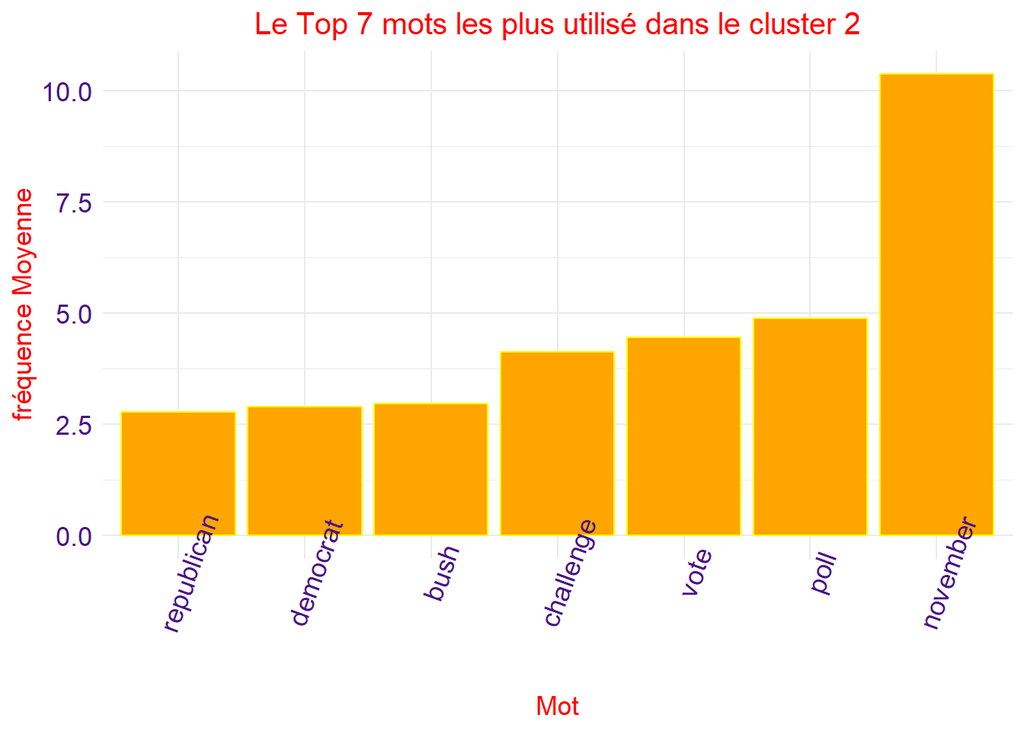

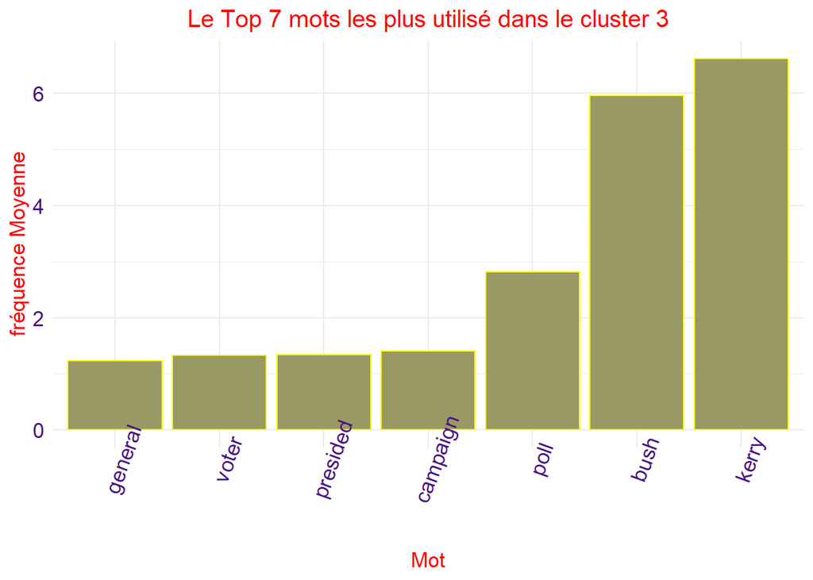

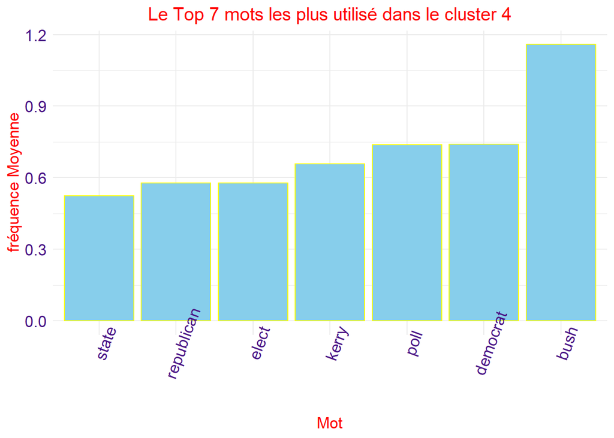

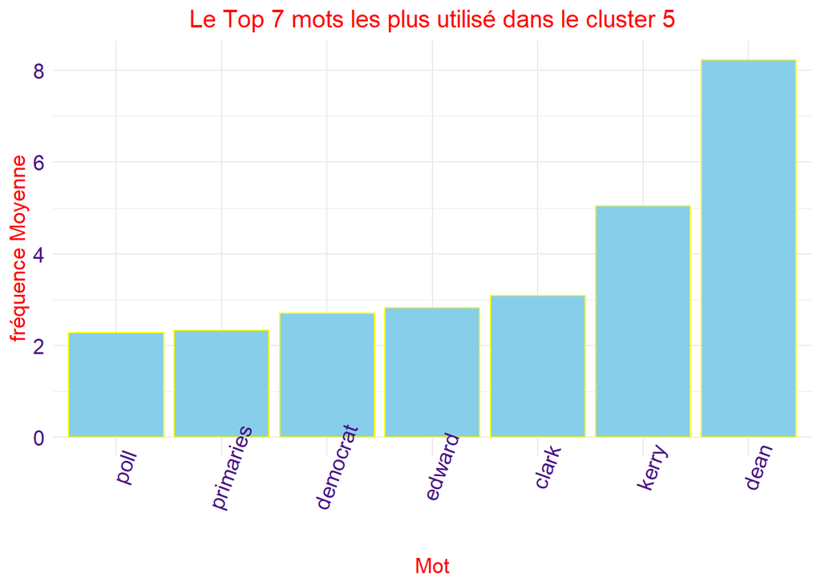

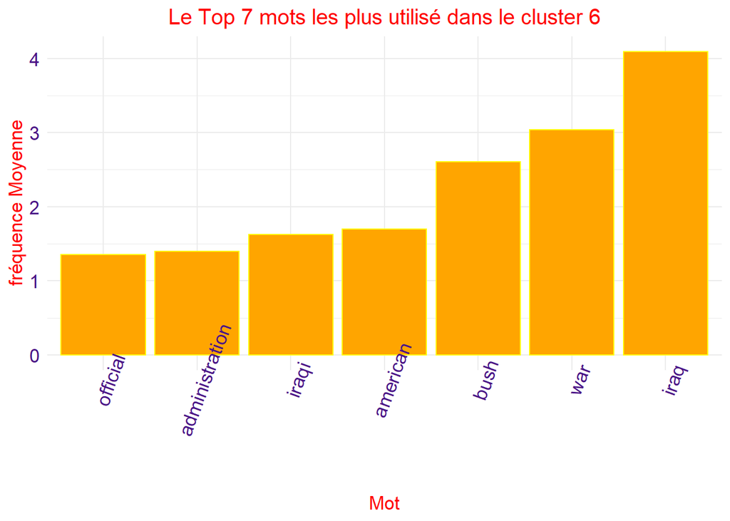

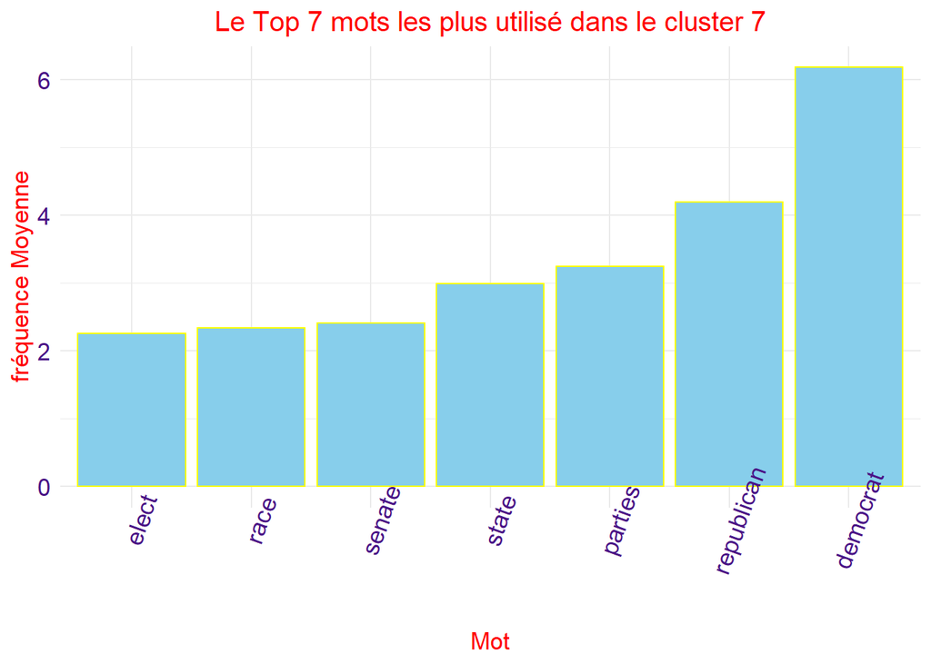

```r
for(i in seq(1,7)){
  top_7_mots_kmeans <- tail(sort(colMeans(subset(dailykos, KMeans_cluster$cluster == i))),7)

  # Récupération de la liste des noms des colonnes
  liste_des_mots_kmeans <- names(top_7_mots_kmeans)

  # Récupération des valeurs de la fréquence de chaque mots
  moyenne_mots_kmeans <- as.vector(top_7_mots_kmeans)

  # Créons un dataframe avec le nom et la valeur de chaque mot
  top_7_mots_kmeans <- data.frame(Mot = liste_des_mots_kmeans,Moyenne_mots = moyenne_mots_kmeans)

  # Organisons cela par ordre décroissant
  top_7_mots_kmeans$Mot <- factor(top_7_mots_kmeans$Mot, levels = top_7_mots_kmeans$Mot[order(top_7_mots_kmeans$Moyenne_mots,decreasing = FALSE)])

  # Palette de couleur
  palette_de_couleur <- c('#F8766D','#999966','#79a6d2','#00BF7D','orange','skyblue','#F8766D')

  # Création des graphes
  graphe_top_7_mots <- ggplot(top_7_mots_kmeans, aes(x = Mot, y = Moyenne_mots)) +
                       geom_bar(stat = "identity", color = "yellow", fill = sample(palette_de_couleur,1,replace = TRUE)) +
                       theme_minimal() +
                       ggtitle(paste("Le Top 7 mots les plus utilisé dans le cluster",i)) +
                       xlab("Mot") +
                       ylab("fréquence Moyenne") +
                       theme(plot.title = element_text(size = 15,colour="red", hjust = 0.5)) +
                       theme(axis.text.x = element_text(size = 13, color = "#4A1486",angle = 70),
                             axis.text.y = element_text(size = 13, color = "#4A1486"),
                             axis.title.x = element_text(size = 13, color = "red"),
                             axis.title.y = element_text(size = 13, color = "red"))


  # Afficher les graphes
  plot(graphe_top_7_mots)
}
```

*Conclusion:* On peut, d’après ce qui précède voir de quoi parle chaque groupe de Cluster, rien que on régardant les mots les plus utilisés.

### Quelle Meilleur Cluster Correspond au partie Démocratique?

```r
# D'après ce qui précède, on peut voir que le Cluster 5 est le Cluster le plus aproprié. Nous avons des mots tels que : "Dean", "Kerry", "Edward", "Democrate"
```

### Comparons comment les observations ont été assignés au Clusters dans loe cas du hierarchical clustering et du K-Means clustering

on utilise la fonction *table*

```r
HCluster_vs_KMeansCluster <- table(Cluster_Hierarchique_dailykos, KMeans_cluster$cluster)
HCluster_vs_KMeansCluster
```

```
##
## Cluster_Hierarchique_dailykos    1    2    3    4    5    6    7
##                             1    3    0  110 1026   11   62   54
##                             2    0  320    1    0    0    0    0
##                             3   85    8   24   67    9   42  139
##                             4   10    0  123    0    5    0    1
##                             5   52    1   34  141    0  171    8
##                             6    0    0    0  710    2    0    2
##                             7    0    0    8   83  117    0    1
```

### Et si nous voulons les résultat en Pourcentage (prop.table)

```r
# Renommons notre variable Kmeans
KMeans_cluster_dailykos <- KMeans_cluster$cluster

HCluster_vs_KMeansCluster <- table(Cluster_Hierarchique_dailykos, KMeans_cluster_dailykos)
pourcentage <- round(prop.table(HCluster_vs_KMeansCluster,2),3)*100

# Affichons le résultat
pourcentage
```

```
##                              KMeans_cluster_dailykos
## Cluster_Hierarchique_dailykos    1    2    3    4    5    6    7
##                             1  2.0  0.0 36.7 50.6  7.6 22.5 26.3
##                             2  0.0 97.3  0.3  0.0  0.0  0.0  0.0
##                             3 56.7  2.4  8.0  3.3  6.2 15.3 67.8
##                             4  6.7  0.0 41.0  0.0  3.5  0.0  0.5
##                             5 34.7  0.3 11.3  7.0  0.0 62.2  3.9
##                             6  0.0  0.0  0.0 35.0  1.4  0.0  1.0
##                             7  0.0  0.0  2.7  4.1 81.2  0.0  0.5
```

*Conclusion:* d’après ce qui précède, on peut en déduire les interprétations suivantes: - Le Cluster Kmeans 5 a pour coorespondance le cluster Hierarchique 7 - Le Cluster Kmeans 2 a pour coorespondance le cluster Hierarchique 2 - Le Cluster Kmeans 7 a pour coorespondance le cluster Hierarchique 3 - Le Cluster Kmeans 6 a pour coorespondance le cluster Hierarchique 5 - Aucun Cluster du Hierarchique ne contient plus de 50% du cluster 3 du Kmeans

# Conclusion:

**Nous avons pu voir comment voir comment fonctionne le Clustering Hierarchique et le K-moyenne(K-Means) pour effectuer ce que l’on appelle, le Clustering de document. A vous de voir lequelle de ces 2 techniques vous semble facile et / ou la plus approprié pour chaque situation.**😎